# Projets tutorés 2 | Devoir 2

YAHIA Mohammed Rafik

2023-04-07

# 1 Introduction

The excel files needed in this part are :

- dm for Protocole information (ARM -> Bup-Nx / Clon)
- ds for Time information (DSSTDY -> Discharge day)
- lb for Opiate Urine tests (LBTEST -> Negative)

# 2 Objective 01 : Graphical representation of participants during the study

Importing the necessary libraries

```r
require(tidyverse)
require(stringr)
require(gridExtra)
require(gtsummary)
require(gt)
require(kableExtra)
require(spatstat.utils)
```

Importing excel files

```r
## In patient protocol (113 IN patients 77+36).

# DM Table with variable that indicates the ARM.
dm <- read.csv("ascii-data-files nida-ctn-0001-20230318/dm.csv", header = T, dec = ".")

# DS Table with variables that indicates remaining patients
ds <- read.csv("ascii-data-files nida-ctn-0001-20230318/ds.csv", header = T, dec = ".")
```

Filtering patients according to our selection criteria

```r
## Filtering the imported excel file
tabDSfilter <- ds %>% select(USUBJID, DSDECOD, VISIT, VISITNUM, DSSTDY, EPOCH) %>%
  filter((!VISIT %in% c("BASELINE, ANY DAY PRIOR TO FIRST DOSE")),
         (!DSDECOD %in% c("VOLUNTARY TRANSFERRED TO ANOTHER TREATMENT PROGRAM (INDICATE TYPE)","DISCHARGED FOR OTHER (SPECIFY)"))) %>%
  select(USUBJID,DSSTDY) %>%
  group_by(USUBJID) %>%
  filter(!is.na(DSSTDY)) %>%
  filter(DSSTDY > 0) %>%
  filter(DSSTDY == min(DSSTDY)) %>%
  distinct()
```

Merging the two excel files

```r
## Adding the ARM column.
tabDSfilter <- left_join(tabDSfilter, dm, by= "USUBJID")
tabDSfilter <- tabDSfilter %>% select(USUBJID, DSSTDY, ARM, EPOCH)
```

We generate dataframes for the ggplot input (IN Protocole)

```r
## Preparing the IN Protocole dataframes for ggplot
## Bup IN patients.
tabDSfinalBUP01 <-tabDSfilter %>%
  filter(ARM=="BUPRENORPHINE/NALOXONE") %>%
  group_by(DSSTDY) %>%
  # a better way would be to automatize this with some sort of loop IN BIND ROWS
  mutate(DSSTDY = if_else(DSSTDY > 14, 14, DSSTDY)) %>%
  summarize(count = n_distinct(USUBJID)) %>%
  bind_rows(data.frame(DSSTDY = c(2, 4, 6, 11, 12), count = c(0, 0, 0, 0, 0))) %>%
  arrange(DSSTDY) %>%
  mutate(negcount = revcumsum(count))

## Clonidine IN patients.
tabDSfinalCLON01 <- tabDSfilter %>%
  filter(ARM=="CLONIDINE") %>%
  mutate(DSSTDY = if_else(DSSTDY > 14, 14, DSSTDY)) %>%
  group_by(DSSTDY) %>%
  summarize(count = n_distinct(USUBJID)) %>%
  bind_rows(data.frame(DSSTDY = c(12, 13), count = c(0, 0))) %>%
  arrange(DSSTDY) %>%
  mutate(negcount = revcumsum(count))
```

We redo the same thing for OUT Protocole, to end up with 4 dataframes that we can generate plots from

```r
## Out patient protocol (230 OUT patients 156+74)
dm2 <- read.csv("ascii-data-files nida-ctn-0002-20230318/dm.csv", header = T, dec = ".")

ds2 <- read.csv("ascii-data-files nida-ctn-0002-20230318/ds.csv", header = T, dec = ".")

tabDSfilter2 <- ds2 %>% select(USUBJID, DSDECOD, VISIT, VISITNUM, DSSTDY, EPOCH) %>%
  filter((!VISIT %in% c("BASELINE, ANY DAY PRIOR TO FIRST DOSE")),
         (!DSDECOD %in% c("VOLUNTARY TRANSFERRED TO ANOTHER TREATMENT PROGRAM (INDICATE TYPE)","DISCHARGED FOR OTHER (SPECIFY)"))) %>%
  select(USUBJID,DSSTDY) %>%
  group_by(USUBJID) %>%
  filter(!is.na(DSSTDY)) %>%
  filter(DSSTDY > 0) %>%
  filter(DSSTDY == min(DSSTDY)) %>%
  distinct()

tabDSfilter2 <- left_join(tabDSfilter2, dm2, by= "USUBJID")
tabDSfilter2 <- tabDSfilter2 %>% select(USUBJID, DSSTDY, ARM, EPOCH) %>% filter(!ARM=="SCREEN FAILURE")

# Issue with patient 02_068937. Missing from DS, was he discharged?, he belonged to BUP/NX Protocole.
# We will assume since his absence from DS means he continued the study until the end (D14), thus starting from Day 0 with 230 screening patients for Out patients. Which is the correct number.
x1 <- data.frame(USUBJID="02_068937", DSSTDY=14, ARM="BUPRENORPHINE/NALOXONE")
tabDSfilter2 <- rbind(tabDSfilter2, x1)

## Preparing the OUT Protocole dataframes for ggplot
# Bup OUT patients.
tabDSfinalBUP02 <-tabDSfilter2 %>%
  filter(ARM=="BUPRENORPHINE/NALOXONE") %>%
  group_by(DSSTDY) %>%
  mutate(DSSTDY = if_else(DSSTDY > 14, 14, DSSTDY)) %>%
  summarize(count = n_distinct(USUBJID)) %>%
  bind_rows(data.frame(DSSTDY = c(5, 12), count = c(0, 0))) %>%
  arrange(DSSTDY) %>%
  mutate(negcount = revcumsum(count))

# Clonidine OUT patients.
tabDSfinalCLON02 <-tabDSfilter2 %>%
  filter(ARM=="CLONIDINE") %>%
  mutate(DSSTDY = if_else(DSSTDY > 14, 14, DSSTDY)) %>%
  group_by(DSSTDY) %>%
  summarize(count = n_distinct(USUBJID)) %>%
  bind_rows(data.frame(DSSTDY = c(5, 12), count = c(0, 0))) %>%
  arrange(DSSTDY) %>%
  mutate(negcount = revcumsum(count))
```

Now that we have all the dataframes ready, we start generating the plots.

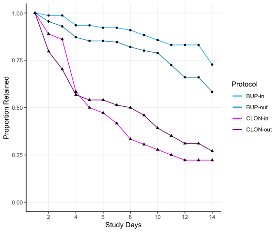

```r
## All 4 tables are generated, now a plot is needed.

ALLplots <- ggplot()+
  geom_line(data=tabDSfinalBUP01, aes(x=DSSTDY, y=negcount/sum(count), colour="deepskyblue"),
            size=0.5) +
  geom_point(data=tabDSfinalBUP01, aes(x=DSSTDY, y=negcount/sum(count)),
              colour="black", size=1) +

  geom_line(data=tabDSfinalBUP02, aes(x=DSSTDY, y=negcount/sum(count),colour="deepskyblue3"),
            size=0.5) +
  geom_point(data=tabDSfinalBUP02, aes(x=DSSTDY, y=negcount/sum(count)),
              colour="black", size=1) +

  geom_line(data=tabDSfinalCLON01, aes(x=DSSTDY, y=negcount/sum(count), colour="magenta"),
            size=0.5) +
  geom_point(data=tabDSfinalCLON01, aes(x=DSSTDY, y=negcount/sum(count)),
             shape=17, colour="black", size=1.5) +

  geom_line(data=tabDSfinalCLON02, aes(x=DSSTDY, y=negcount/sum(count), colour="magenta4"),
            size=0.5) +
  geom_point(data=tabDSfinalCLON02, aes(x=DSSTDY, y=negcount/sum(count)),
             shape=17, colour="black", size=1.5)+
  ylim(0,1)+
  scale_x_continuous(breaks=c(2,4,6,8,10,12,14))+
  theme_classic()+
  theme(panel.grid.major = element_line(colour = "gray95"))+
  xlab("Study Days") + ylab("Proportion Retained")+
  scale_color_identity(name = "Protocol",
                       breaks = c("deepskyblue", "deepskyblue3", "magenta", "magenta4"),
                       labels = c("BUP-in", "BUP-out", "CLON-in", "CLON-out"),
                       guide = "legend")
ALLplots
```

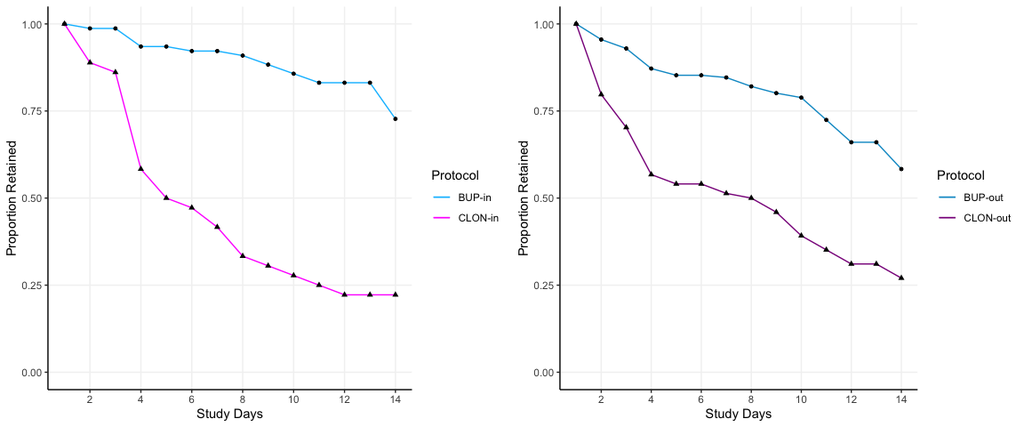

```r
## In Protocol
Inplots <- ggplot()+

  geom_line(data=tabDSfinalBUP01, aes(x=DSSTDY, y=negcount/sum(count), colour="deepskyblue"),
            size=0.5) +
  geom_point(data=tabDSfinalBUP01, aes(x=DSSTDY, y=negcount/sum(count)),
             colour="black", size=1) +

  geom_line(data=tabDSfinalCLON01, aes(x=DSSTDY, y=negcount/sum(count), colour="magenta"),
            size=0.5) +
  geom_point(data=tabDSfinalCLON01, aes(x=DSSTDY, y=negcount/sum(count)),
             shape=17, colour="black", size=1.5) +
  ylim(0,1)+
  scale_x_continuous(breaks=c(2,4,6,8,10,12,14))+
  theme_classic()+
  theme(panel.grid.major = element_line(colour = "gray95"))+
  xlab("Study Days") + ylab("Proportion Retained")+
  scale_color_identity(name = "Protocol",
                       breaks = c("deepskyblue", "magenta"),
                       labels = c("BUP-in", "CLON-in"),
                       guide = "legend")


## Out protocol
Outplots <- ggplot()+

  geom_line(data=tabDSfinalBUP02, aes(x=DSSTDY, y=negcount/sum(count),colour="deepskyblue3"),
            size=0.5) +
  geom_point(data=tabDSfinalBUP02, aes(x=DSSTDY, y=negcount/sum(count)),
             colour="black", size=1) +

  geom_line(data=tabDSfinalCLON02, aes(x=DSSTDY, y=negcount/sum(count), colour="magenta4"),
            size=0.5) +
  geom_point(data=tabDSfinalCLON02, aes(x=DSSTDY, y=negcount/sum(count)),
             shape=17, colour="black", size=1.5)+
  ylim(0,1)+
  scale_x_continuous(breaks=c(2,4,6,8,10,12,14))+
  theme_classic()+
  theme(panel.grid.major = element_line(colour = "gray95"))+
  xlab("Study Days") + ylab("Proportion Retained")+
  scale_color_identity(name = "Protocol",
                       breaks = c("deepskyblue3", "magenta4"),
                       labels = c("BUP-out", "CLON-out"),
                       guide = "legend")

Arrangedplots <- grid.arrange(Inplots, Outplots, nrow=1)
```

# 3 Objective 02 : Summary table of the study

Importing excel files

```r
# DM table with variable that indicates the ARM.
dm <- read.csv("ascii-data-files nida-ctn-0001-20230318/dm.csv", header = T, dec = ".")

# LB table with variable that indicates opioid test results.
lb <- read.csv("ascii-data-files nida-ctn-0001-20230318/lb.csv", header = T, dec = ".")
```

Filtering patients according to our selection criteria

```r
## Filtering the imported excel file
dm3 <- dm %>% filter(ARM %in% c("CLONIDINE","BUPRENORPHINE/NALOXONE")) %>% select(USUBJID, ARM)

lb3 <- lb %>% filter(EPOCH == "ACTIVE", VISITNUM %in% c(1:14)) #Missing 5 patients from lb3 compared to dm3 when applying this filter. as they are still in screening epoch but have already been assigned in dm database "01_018076" "01_027452" "01_058918" "01_063935" "01_067193".
```

Merging the two excel files

```r
## Adding the ARM column.
list_df10 = list(lb3, dm3)
tabURINE <- list_df10 %>%
  reduce(full_join, by='USUBJID') %>%
  select("USUBJID", "LBTEST", "LBORRES", "LBSTAT", "LBREASND", "LBSPEC", "LBMETHOD", "VISIT", "VISITNUM", "LBDY", "LBDTC", "ARM") #113 patients
```

We redo the same thing for OUT Protocole

```r
lb2 <- read.csv("ascii-data-files nida-ctn-0002-20230318/lb.csv", header = T, dec = ".")

dm4 <- dm2 %>% filter(ARM %in% c("CLONIDINE","BUPRENORPHINE/NALOXONE")) %>% select (USUBJID, ARM)

lb4 <- lb2 %>% filter(EPOCH == "ACTIVE", VISITNUM %in% c(1:14)) #Missing 27 patients from lb4 compared to dm4 when applying this filter.

list_df11 = list(lb4, dm4)
tabURINE2 <- list_df11 %>%
  reduce(full_join, by='USUBJID') %>%
  select("USUBJID", "LBTEST", "LBORRES", "LBSTAT", "LBREASND", "LBSPEC", "LBMETHOD", "VISIT", "VISITNUM", "LBDY", "LBDTC", "ARM") #231 patients
```

Merging the two dataframes (IN + OUT Protocole) Creating the variable with range of days (TESTperiod) Applying the final filter to generate the summary table

```r
## Merging both tables
TableURINE <- rbind(tabURINE, tabURINE2)

## Creating variable with range of days
TableURINE <- TableURINE %>%
  mutate(TESTperiod = ifelse(VISITNUM %in% c(2,3,4,5,6), "Day 3 or 4",
                                       ifelse(VISITNUM %in% c(7,8,9), "Day 7 or 8",
                                              ifelse(VISITNUM %in% c(10,11,12), "Day 10 or 11",
                                                     ifelse(VISITNUM %in% c(13,14,15,16,17), "Day 13 or 14",NA))))) %>%
  mutate(TESTperiod = as.factor(TESTperiod)) %>%
  mutate(TESTperiod = factor(TESTperiod, levels = c(levels(TESTperiod), "Day 0"))) %>%
  mutate(PROTOCOLE = if_else(str_detect(USUBJID, "^01"), "In-patient protocol", "Out-patient protocol")) %>%
  mutate(PROTOCOLE = as.factor(PROTOCOLE)) %>%
  filter(ARM %in% c("CLONIDINE","BUPRENORPHINE/NALOXONE")) %>%
  # Issue with patient 02_036130. Filtered again because after join there was one patient that had SCREEN FAILURE on DM4 but got to the final table through LB4 because he had active epoch tests, which doesn't make sense.
  arrange(VISITNUM)

## Final filter
TableURINEfiltered <- TableURINE %>%
  filter(LBTEST=="OPIATE", LBORRES=="NEGATIVE") %>%
  select("ARM", "TESTperiod", "PROTOCOLE") %>%
  mutate(TESTperiod = fct_relevel(TESTperiod, "Day 0", "Day 3 or 4", "Day 7 or 8", "Day 10 or 11", "Day 13 or 14"))
```

```r
## Summary table.
TableURINEfilteredGT <- TableURINEfiltered %>% tbl_strata(strata = PROTOCOLE, ~.x %>% tbl_summary(by = ARM, label = TESTperiod ~ "Study duration", statistic = all_continuous() ~ "{n} % ({n} / {N})")) %>%
                                       # The issue is in the last part of code (N), the % are taken from the total number of rows and not patients.
                                       # The n_distinct in this case doesn't work because there are multiple combinations for one patient, thus keeping multiple lines per patient and having more than the actual number.
                                       # Also doesn't work because i didn't select USUBJID in TableURINEfiltered, because if i do it will crash.
                                       # The closest i got was by using this function, not within gtsummary as it crashes, # TableURINE %>% summarize(n_unique = length(unique(USUBJID))) %>% pull(n_unique)
                                       # I couldn't find a solution for this within the deadline.
  bold_labels() %>%
  italicize_levels() %>%
  # show_header_names(TableURINEfilteredGT)
  modify_footnote(
    all_stat_cols() ~ "Number of patients") %>%
  # Modifying the header values N to represent the actual number of patients and not the total rows.
  modify_header(
    label = '',
    stat_1_1 = '**Bup-Nx**, N = 77',
    stat_2_1 = '**Clon**, N = 36',
    stat_1_2 = '**Bup-Nx**, N = 156',
    stat_2_2 = '**Clon**, N = 74')

TableURINEfilteredGT
```

|  | **In-patient protocol** **Bup-Nx**, N = 77<sup>1</sup> | **In-patient protocol** **Clon**, N = 36<sup>1</sup> | **Out-patient protocol** **Bup-Nx**, N = 156<sup>1</sup> | **Out-patient protocol** **Clon**, N = 74<sup>1</sup> |
| --- | --- | --- | --- | --- |
| Study duration |  |  |  |  |
| Day 0 | 0 (0%) | 0 (0%) | 0 (0%) | 0 (0%) |
| Day 3 or 4 | 53 (24%) | 14 (33%) | 38 (20%) | 5 (25%) |
| Day 7 or 8 | 62 (28%) | 13 (30%) | 54 (29%) | 6 (30%) |
| Day 10 or 11 | 56 (25%) | 10 (23%) | 52 (28%) | 5 (25%) |
| Day 13 or 14 | 53 (24%) | 6 (14%) | 45 (24%) | 4 (20%) |

<sup>1</sup> Number of patients

# 4 Objective 03 : Statistical test between the treatement groupes

```r
TableURINEfilteredGTstat <- TableURINEfiltered %>% tbl_strata(strata = PROTOCOLE, ~.x %>%
                                       tbl_summary(by = ARM, label = TESTperiod ~ "Study duration", statistic = all_continuous() ~ "{n} % ({n} / {N})") %>%
                                       # The issue is in the last part of code (N), the % are taken from the total number of rows and not patients.
                                       # The n_distinct in this case doesn't work because there are multiple combinations for one patient, thus keeping multiple lines per patient and having more than the actual number.
                                       # Also doesn't work because i didn't select USUBJID in TableURINEfiltered, because if i do it will crash.
                                       # The closest i got was by using this function, not within gtsummary as it crashes, # TableURINE %>% summarize(n_unique = length(unique(USUBJID))) %>% pull(n_unique)
                                       # I couldn't find a solution for this within the deadline.
  add_difference()) %>%
  bold_labels() %>%
  italicize_levels() %>%
  # show_header_names(TableURINEfilteredGT)
  modify_footnote(
    all_stat_cols() ~ "Number of patients") %>%
  # Modifying the header values N to represent the actual number of patients and not the total rows.
  modify_header(
    label = '',
    stat_1_1 = '**Bup-Nx**, N = 77',
    stat_2_1 = '**Clon**, N = 36',
    estimate_1 = '**SMD**',
    stat_1_2 = '**Bup-Nx**, N = 156',
    stat_2_2 = '**Clon**, N = 74',
    estimate_2 = '**SMD**',)

## Highlighting the statistical test results
TableURINEfilteredGTstatOBJ <- TableURINEfilteredGTstat %>%
  # convert gtsummary table to gt
  as_gt() %>%
  # use gt::tab_style() to shade column
  gt::tab_style(
    style = list(gt::cell_fill(color = "#e1f1fd"), css = "font-size: 12px"), locations = gt::cells_body(columns = c(ci_1,ci_2)))
TableURINEfilteredGTstatOBJ
```

|  | **In-patient protocol** **Bup-Nx**, N = 77<sup>1</sup> | **In-patient protocol** **Clon**, N = 36<sup>1</sup> | **In-patient protocol** **SMD**<sup>2</sup> | **In-patient protocol** **95% CI**<sup>2,3</sup> | **Out-patient protocol** **Bup-Nx**, N = 156<sup>1</sup> | **Out-patient protocol** **Clon**, N = 74<sup>1</sup> | **Out-patient protocol** **SMD**<sup>2</sup> | **Out-patient protocol** **95% CI**<sup>2,3</sup> |
| --- | --- | --- | --- | --- | --- | --- | --- | --- |
| Study duration |  |  | 0.29 | -0.04, 0.62 |  |  | 0.14 | -0.32, 0.60 |
| Day 0 | 0 (0%) | 0 (0%) |  |  | 0 (0%) | 0 (0%) |  |  |
| Day 3 or 4 | 53 (24%) | 14 (33%) |  |  | 38 (20%) | 5 (25%) |  |  |
| Day 7 or 8 | 62 (28%) | 13 (30%) |  |  | 54 (29%) | 6 (30%) |  |  |
| Day 10 or 11 | 56 (25%) | 10 (23%) |  |  | 52 (28%) | 5 (25%) |  |  |
| Day 13 or 14 | 53 (24%) | 6 (14%) |  |  | 45 (24%) | 4 (20%) |  |  |

<sup>1</sup> Number of patients  
<sup>2</sup> Standardized Mean Difference  
<sup>3</sup> CI = Confidence Interval

Note : The N number showed under each treatement is hardcoded, which means the % in each Day are taken according to the original N number which makes them false, thus making statistical tests false as well. The problematic part is highlighted in the code with comments below it and more explanation.

# 5 Annex

## 5.1 R script

```r
#Devoir 2
require(tidyverse)
require(stringr)
require(gridExtra)
require(gtsummary)
require(gt)
require(spatstat.utils)


#### Objective 01 : Graphical representation of patients evolution during the 14 days

#### In patient protocol (113 IN patients 77+36)

### DM Table with variable that indicates the ARM.
dm <- read.csv("ascii-data-files nida-ctn-0001-20230318/dm.csv", header = T, dec = ".")

### DS Table with variables that indicates remaining patients
ds <- read.csv("ascii-data-files nida-ctn-0001-20230318/ds.csv", header = T, dec = ".")

tabDSfilter <- ds %>% select(USUBJID, DSDECOD, VISIT, VISITNUM, DSSTDY, EPOCH) %>%
  filter((!VISIT %in% c("BASELINE, ANY DAY PRIOR TO FIRST DOSE")),
         (!DSDECOD %in% c("VOLUNTARY TRANSFERRED TO ANOTHER TREATMENT PROGRAM (INDICATE TYPE)","DISCHARGED FOR OTHER (SPECIFY)"))) %>%
  select(USUBJID,DSSTDY) %>%
  group_by(USUBJID) %>%
  filter(!is.na(DSSTDY)) %>%
  filter(DSSTDY > 0) %>%
  filter(DSSTDY == min(DSSTDY)) %>%
  distinct()

# Adding the ARM column.
tabDSfilter <- left_join(tabDSfilter, dm, by= "USUBJID")
tabDSfilter <- tabDSfilter %>% select(USUBJID, DSSTDY, ARM, EPOCH)

## Preparing the IN Protocole dataframes for ggplot
# Bup IN patients.
tabDSfinalBUP01 <-tabDSfilter %>%
  filter(ARM=="BUPRENORPHINE/NALOXONE") %>%
  group_by(DSSTDY) %>%
  # a better way would be to automatize this with some sort of loop IN BIND ROWS
  mutate(DSSTDY = if_else(DSSTDY > 14, 14, DSSTDY)) %>%
  summarize(count = n_distinct(USUBJID)) %>%
  bind_rows(data.frame(DSSTDY = c(2, 4, 6, 11, 12), count = c(0, 0, 0, 0, 0))) %>%
  arrange(DSSTDY) %>%
  mutate(negcount = revcumsum(count))

# Clonidine IN patients.
tabDSfinalCLON01 <- tabDSfilter %>%
  filter(ARM=="CLONIDINE") %>%
  mutate(DSSTDY = if_else(DSSTDY > 14, 14, DSSTDY)) %>%
  group_by(DSSTDY) %>%
  summarize(count = n_distinct(USUBJID)) %>%
  bind_rows(data.frame(DSSTDY = c(12, 13), count = c(0, 0))) %>%
  arrange(DSSTDY) %>%
  mutate(negcount = revcumsum(count))


#### Out patient protocol (We should have 230 OUT patients 156+74)
dm2 <- read.csv("ascii-data-files nida-ctn-0002-20230318/dm.csv", header = T, dec = ".")
ds2 <- read.csv("ascii-data-files nida-ctn-0002-20230318/ds.csv", header = T, dec = ".")

tabDSfilter2 <- ds2 %>% select(USUBJID, DSDECOD, VISIT, VISITNUM, DSSTDY, EPOCH) %>%
  filter((!VISIT %in% c("BASELINE, ANY DAY PRIOR TO FIRST DOSE")),
         (!DSDECOD %in% c("VOLUNTARY TRANSFERRED TO ANOTHER TREATMENT PROGRAM (INDICATE TYPE)","DISCHARGED FOR OTHER (SPECIFY)"))) %>%
  select(USUBJID,DSSTDY) %>%
  group_by(USUBJID) %>%
  filter(!is.na(DSSTDY)) %>%
  filter(DSSTDY > 0) %>%
  filter(DSSTDY == min(DSSTDY)) %>%
  distinct()

tabDSfilter2 <- left_join(tabDSfilter2, dm2, by= "USUBJID")
tabDSfilter2 <- tabDSfilter2 %>% select(USUBJID, DSSTDY, ARM, EPOCH) %>% filter(!ARM=="SCREEN FAILURE")

# Issue with patient 02_068937. Missing from DS, was he discharged?, he belonged to BUP/NX Protocole.
# We will assume since his absence from DS means he continued the study until the end (D14), thus starting from Day 0 with 230 screening patients for Out patients. Which is the correct number.
x1 <- data.frame(USUBJID="02_068937", DSSTDY=14, ARM="BUPRENORPHINE/NALOXONE")
tabDSfilter2 <- rbind(tabDSfilter2, x1)

## Preparing the OUT Protocole dataframes for ggplot
# Bup OUT patients.
tabDSfinalBUP02 <-tabDSfilter2 %>%
  filter(ARM=="BUPRENORPHINE/NALOXONE") %>%
  group_by(DSSTDY) %>%
  mutate(DSSTDY = if_else(DSSTDY > 14, 14, DSSTDY)) %>%
  summarize(count = n_distinct(USUBJID)) %>%
  bind_rows(data.frame(DSSTDY = c(5, 12), count = c(0, 0))) %>%
  arrange(DSSTDY) %>%
  mutate(negcount = revcumsum(count))

# Clonidine OUT patients.
tabDSfinalCLON02 <-tabDSfilter2 %>%
  filter(ARM=="CLONIDINE") %>%
  mutate(DSSTDY = if_else(DSSTDY > 14, 14, DSSTDY)) %>%
  group_by(DSSTDY) %>%
  summarize(count = n_distinct(USUBJID)) %>%
  bind_rows(data.frame(DSSTDY = c(5, 12), count = c(0, 0))) %>%
  arrange(DSSTDY) %>%
  mutate(negcount = revcumsum(count))

#All 4 tables are generated, now a plot is needed.
ALLplots <- ggplot()+
  # blue plot BUP in patient
  geom_line(data=tabDSfinalBUP01, aes(x=DSSTDY, y=negcount/sum(count), colour="deepskyblue"),
            size=0.5) +
  geom_point(data=tabDSfinalBUP01, aes(x=DSSTDY, y=negcount/sum(count)),
              colour="black", size=1) +
  # darker blue plot BUP out patient
  geom_line(data=tabDSfinalBUP02, aes(x=DSSTDY, y=negcount/sum(count),colour="deepskyblue3"),
            size=0.5) +
  geom_point(data=tabDSfinalBUP02, aes(x=DSSTDY, y=negcount/sum(count)),
              colour="black", size=1) +

  # magenta plot CLON in patient
  geom_line(data=tabDSfinalCLON01, aes(x=DSSTDY, y=negcount/sum(count), colour="magenta"),
            size=0.5) +
  geom_point(data=tabDSfinalCLON01, aes(x=DSSTDY, y=negcount/sum(count)),
             shape=17, colour="black", size=1.5) +
  # darker magenta plot CLON out patient
  geom_line(data=tabDSfinalCLON02, aes(x=DSSTDY, y=negcount/sum(count), colour="magenta4"),
            size=0.5) +
  geom_point(data=tabDSfinalCLON02, aes(x=DSSTDY, y=negcount/sum(count)),
             shape=17, colour="black", size=1.5)+
  ylim(0,1)+
  scale_x_continuous(breaks=c(2,4,6,8,10,12,14))+
  theme_classic()+
  theme(panel.grid.major = element_line(colour = "gray95"))+
  xlab("Study Days") + ylab("Proportion Retained")+
  scale_color_identity(name = "Protocol",
                       breaks = c("deepskyblue", "deepskyblue3", "magenta", "magenta4"),
                       labels = c("BUP-in", "BUP-out", "CLON-in", "CLON-out"),
                       guide = "legend")
ALLplots


#In Protocol
Inplots <- ggplot()+
  # blue plot BUP in patient
  geom_line(data=tabDSfinalBUP01, aes(x=DSSTDY, y=negcount/sum(count), colour="deepskyblue"),
            size=0.5) +
  geom_point(data=tabDSfinalBUP01, aes(x=DSSTDY, y=negcount/sum(count)),
             colour="black", size=1) +
  # magenta plot CLON in patient
  geom_line(data=tabDSfinalCLON01, aes(x=DSSTDY, y=negcount/sum(count), colour="magenta"),
            size=0.5) +
  geom_point(data=tabDSfinalCLON01, aes(x=DSSTDY, y=negcount/sum(count)),
             shape=17, colour="black", size=1.5) +
  ylim(0,1)+
  scale_x_continuous(breaks=c(2,4,6,8,10,12,14))+
  theme_classic()+
  theme(panel.grid.major = element_line(colour = "gray95"))+
  xlab("Study Days") + ylab("Proportion Retained")+
  scale_color_identity(name = "Protocol",
                       breaks = c("deepskyblue", "magenta"),
                       labels = c("BUP-in", "CLON-in"),
                       guide = "legend")
```

```r
#Out protocol
Outplots <- ggplot()+
  # darker blue plot BUP out patient
  geom_line(data=tabDSfinalBUP02, aes(x=DSSTDY, y=negcount/sum(count),colour="deepskyblue3"),
            size=0.5) +
  geom_point(data=tabDSfinalBUP02, aes(x=DSSTDY, y=negcount/sum(count)),
             colour="black", size=1) +
  # darker magenta plot CLON out patient
  geom_line(data=tabDSfinalCLON02, aes(x=DSSTDY, y=negcount/sum(count), colour="magenta4"),
            size=0.5) +
  geom_point(data=tabDSfinalCLON02, aes(x=DSSTDY, y=negcount/sum(count)),
             shape=17, colour="black", size=1.5)+
  ylim(0,1)+
  scale_x_continuous(breaks=c(2,4,6,8,10,12,14))+
  theme_classic()+
  theme(panel.grid.major = element_line(colour = "gray95"))+
  xlab("Study Days") + ylab("Proportion Retained")+
  scale_color_identity(name = "Protocol",
                       breaks = c("deepskyblue3", "magenta4"),
                       labels = c("BUP-out", "CLON-out"),
                       guide = "legend")

Arrangedplots <- grid.arrange(Inplots, Outplots, nrow=1)

#We made overall 4 plots :
#The first one has all of the protocoles together #ALLplots
#The last one has them split in two screens #Arrangedplots
#The second one has In protocole #Inplots
#The third one has Out protocole #Outplots

####

#### Objective 02 : Creating a table that summarizes the study results.
# Like Flow chart that we filled, but this time with more detail about who reached each day and had a negative test result for opoids.

# Importing lb database containg opioid test results, and dm with arm.
lb <- read.csv("ascii-data-files nida-ctn-0001-20230318/lb.csv", header = T, dec = ".")
lb2 <- read.csv("ascii-data-files nida-ctn-0002-20230318/lb.csv", header = T, dec = ".")
dm3 <- dm %>% filter(ARM %in% c("CLONIDINE","BUPRENORPHINE/NALOXONE")) %>% select(USUBJID, ARM)
dm4 <- dm2 %>% filter(ARM %in% c("CLONIDINE","BUPRENORPHINE/NALOXONE")) %>% select (USUBJID, ARM)
lb3 <- lb %>% filter(EPOCH == "ACTIVE", VISITNUM %in% c(1:14)) #Missing 5 patients from lb3 compared to dm3 when applying this filter. as they are still in screening epoch but have already been assigned in dm database "01_018076" "01_027452" "01_058918" "01_063935" "01_067193".
lb4 <- lb2 %>% filter(EPOCH == "ACTIVE", VISITNUM %in% c(1:14)) #Missing 27 patients from lb4 compared to dm4 when applying this filter.

# Adding the ARM column.
list_df10 = list(lb3, dm3)
tabURINE <- list_df10 %>%
  reduce(full_join, by='USUBJID') %>%
  select("USUBJID", "LBTEST", "LBORRES", "LBSTAT", "LBREASND", "LBSPEC", "LBMETHOD", "VISIT", "VISITNUM", "LBDY", "LBDTC", "ARM") #113 patients

list_df11 = list(lb4, dm4)
tabURINE2 <- list_df11 %>%
  reduce(full_join, by='USUBJID') %>%
  select("USUBJID", "LBTEST", "LBORRES", "LBSTAT", "LBREASND", "LBSPEC", "LBMETHOD", "VISIT", "VISITNUM", "LBDY", "LBDTC", "ARM") #231 patients


# Merging both tables
TableURINE <- rbind(tabURINE, tabURINE2)

TableURINE <- TableURINE %>%
  mutate(TESTperiod = ifelse(VISITNUM %in% c(2,3,4,5,6), "Day 3 or 4",
                                       ifelse(VISITNUM %in% c(7,8,9), "Day 7 or 8",
                                              ifelse(VISITNUM %in% c(10,11,12), "Day 10 or 11",
                                                     ifelse(VISITNUM %in% c(13,14,15,16,17), "Day 13 or 14",NA))))) %>%
  mutate(TESTperiod = as.factor(TESTperiod)) %>%
  mutate(TESTperiod = factor(TESTperiod, levels = c(levels(TESTperiod), "Day 0"))) %>%
  mutate(PROTOCOLE = if_else(str_detect(USUBJID, "^01"), "In-patient protocol", "Out-patient protocol")) %>%
  mutate(PROTOCOLE = as.factor(PROTOCOLE)) %>%
  filter(ARM %in% c("CLONIDINE","BUPRENORPHINE/NALOXONE")) %>%
  # Issue with patient 02_036130. Filtered again because after join there was one patient that had SCREEN FAILURE on DM4 but got to the final table through LB4 because he had active epoch tests, which doesn't make sense.
  arrange(VISITNUM)


## Final table with statistical test.
TableURINEfiltered <- TableURINE %>%
  filter(LBTEST=="OPIATE", LBORRES=="NEGATIVE") %>%
  select("ARM", "TESTperiod", "PROTOCOLE") %>%
  mutate(TESTperiod = fct_relevel(TESTperiod, "Day 0", "Day 3 or 4", "Day 7 or 8", "Day 10 or 11", "Day 13 or 14"))

TableURINEfilteredGT <- TableURINEfiltered %>% tbl_strata(strata = PROTOCOLE, ~.x %>%
                                       tbl_summary(by = ARM, label = TESTperiod ~ "Study duration", statistic = all_continuous() ~ "{n} % ({n} / {N})") %>%
                                       # The issue is in the last part of code (N), the % are taken from the total number of rows and not patients.
                                       # The n_distinct in this case doesn't work because there are multiple combinations for one patient, thus keeping multiple lines per patient and having more than the actual number.
                                       # Also doesn't work because i didn't select USUBJID in TableURINEfiltered, because if i do it will crash.
                                       # The closest i got was by using this function, not within gtsummary as it crashes, # TableURINE %>% summarize(n_unique = length(unique(USUBJID))) %>% pull(n_unique)
                                       # I couldn't find a solution for this within the deadline.
                                       add_difference()) %>%
  bold_labels() %>%
  italicize_levels() %>%
  # show_header_names(TableURINEfilteredGT)
  modify_footnote(
    all_stat_cols() ~ "Number of patients") %>%
  # Modifying the header values N to represent the actual number of patients and not the total rows.
  modify_header(
    label = '',
    stat_1_1 = '**Bup-Nx**, N = 77',
    stat_2_1 = '**Clonidine**, N = 36',
    estimate_1 = '**SMD**',
    stat_1_2 = '**Bup-Nx**, N = 156',
    stat_2_2 = '**Clonidine**, N = 74',
    estimate_2 = '**SMD**')

## Highlighting the statistical test results
TableURINEfilteredGTobj <- TableURINEfilteredGT %>%
  # convert gtsummary table to gt
  as_gt() %>%
  # use gt::tab_style() to shade column
  gt::tab_style(
    style = list(gt::cell_fill(color = "#e1f1fd"), css = "font-size: 12px"),
    locations = gt::cells_body(columns = c(ci_1,ci_2)))
```

```r
TableURINEfilteredGTobj

# Useful code for comparisons of different databases.
# Find values in df1$values that are not in df2$values
#not_in_df2 <- tabURINE2$USUBJID[!tabURINE2$USUBJID %in% tabDSfilter2$USUBJID]
#print(not_in_df2)
# Output: [1] "A" "B"

# Find values in df2$values that are not in df1$values
#not_in_df1 <- tabDSfilter2$USUBJID[!tabDSfilter2$USUBJID %in% tabURINE2$USUBJID]
#print(not_in_df1)
# Output: [1] "F" "G"


# One last remaining step is in the table to show the actual N number per patient and not the total of rows
# I searched everywhere but couldn't find a solution
# ?add_n
# ?all_stat_cols

# Useful code for comparisons of different databases.
# Find values in df1$values that are not in df2$values
# not_in_df2 <- df1$values[!df1$values %in% df2$values]
# print(not_in_df2)
# Output: [1] "A" "B"

# Find values in df2$values that are not in df1$values
# not_in_df1 <- df2$values[!df2$values %in% df1$values]
# print(not_in_df1)
# Output: [1] "F" "G"

# How many patients are in a table.
# length(unique(dm4$USUBJID))
# length(unique(lb4$USUBJID))

# https://www.danieldsjoberg.com/gtsummary/articles/tbl_summary.html
```